# Spring 2025-HW2 Solutions-R

### 2025-01-01

```r
knitr::opts_chunk$set(echo = TRUE)
```

## This notebook should be set to the correct Kernel before working on the questions.

## **Sales and Customer Interaction Dataset**

In homework 2, we again visit the sales dataset used in homework 1. As a reminder, the dataset contains the following columns:

**1) Customer_ID**: Unique identifier for each customer.

**2) Product_Category**: Category of purchased product (e.g. 'Books', 'Electronics', 'Toys', 'Clothing', etc.).

**3) Purchase_Amount**: Total amount, in dollars, spent on each purchase.

**4) Purchase_Date**: Date of transaction.

**5) Customer_Age**: Age of customer at time of purchase.

**6) Customer_Gender**: Gender of the customer ('Male' or 'Female').

**7) Store_Location**: Location of store where purchase occurred.

**8) Satisfaction_Score (response variable)** : Numeric response variable indicating customer's satisfaction level from 0 (least satisfied) to 10 (most satisfied).

```r
set.seed(17) # Seed set to ensure reproducible results. DO NOT CHANGE SEED OR RESET THE SAME SEED IN A LATER CELL.

# Load the dataset
sales_data <- read.csv("cleaned_sales_dataset.csv", header = TRUE)

# Convert specified columns to categorical variables
sales_data$Product_Category <- as.factor(sales_data$Product_Category)
sales_data$Customer_Gender <- as.factor(sales_data$Customer_Gender)
sales_data$Store_Location <- as.factor(sales_data$Store_Location)

# Convert Purchase_Date to Date format
sales_data$Purchase_Date <- as.Date(sales_data$Purchase_Date, format="%m/%d/%Y")

# Split the data into 80% training and 20% test sets
sample_int_ceiling <- sample.int(n = nrow(sales_data),
                                 size = ceiling(.80 * nrow(sales_data)), replace = FALSE)
train_sales_data <- sales_data[sample_int_ceiling, ]
test_sales_data <- sales_data[-sample_int_ceiling, ]

# Remove row names
rownames(train_sales_data) <- NULL
rownames(test_sales_data) <- NULL
```

```r
# Load necessary libraries
library(dplyr)
library(hexbin)
library(ggplot2)
library(car)
```

## Question 1: Data Preparation (6 points)

**1a) Using the dataframe, "sales_data", sort by the Satisfaction_Score (from low to high), print the first 10 rows of the dataframe, then print minimum, maximum, 10th percentile, 25th percentile, 50th percentile, 75th percentile, 90th percentile, average, and median Satisfaction_Score. Note: the sorting should be permanently (not temporarily) stored unless otherwise stated.** (3 points)

```r
# Sort the dataframe by Satisfaction_Score from low to high
sales_data <- sales_data[order(sales_data$Satisfaction_Score), ]

# Print the first 10 rows of the sorted dataframe
print(head(sales_data, 10))

# Calculate and print the required statistics for Satisfaction_Score
satisfaction_stats <- summary(sales_data$Satisfaction_Score)
percentiles <- quantile(sales_data$Satisfaction_Score, probs = c(0.10, 0.25, 0.50, 0.75, 0.90))

cat("Minimum Satisfaction Score:", satisfaction_stats["Min."], "\n")
cat("Maximum Satisfaction Score:", satisfaction_stats["Max."], "\n")
cat("10th Percentile Satisfaction Score:", percentiles[1], "\n")
cat("25th Percentile Satisfaction Score:", percentiles[2], "\n")
cat("50th Percentile Satisfaction Score:", percentiles[3], "\n")
cat("75th Percentile Satisfaction Score:", percentiles[4], "\n")
cat("90th Percentile Satisfaction Score:", percentiles[5], "\n")
cat("Average Satisfaction Score:", mean(sales_data$Satisfaction_Score), "\n")
cat("Median Satisfaction Score:", median(sales_data$Satisfaction_Score), "\n")
```

```
    Customer_ID Product_Category Purchase_Amount Purchase_Date Customer_Age
743         850             Toys          143.16    2024-10-21           30
593         713             Toys           39.94    2024-09-03           20
440         555             Toys          374.99    2024-09-25           52
777         883             Toys          463.96    2024-08-19           26
269         359         Clothing          453.28    2024-03-17           37
36          136             Toys           40.29    2024-06-07           62
426         538             Toys          384.70    2024-12-04           42
245         335             Toys          555.06    2024-07-01           54
868         969             Toys           63.00    2024-04-02           35
872         972             Toys          655.22    2024-06-18           22
    Customer_Gender Store_Location Satisfaction_Score
743          Female         Denver           2.727493
593          Female         Boston           3.529635
440          Female         Boston           3.566404
777          Female      San Diego           3.643812
269            Male  San Francisco           3.783034
36             Male      Las Vegas           3.865658
426            Male      Las Vegas           3.906121
245          Female      San Diego           3.999035
868          Female    Los Angeles           4.048364
872          Female  San Francisco           4.160874
Minimum Satisfaction Score: 2.727493
Maximum Satisfaction Score: 10
10th Percentile Satisfaction Score: 5.665529
25th Percentile Satisfaction Score: 6.411953
50th Percentile Satisfaction Score: 7.508549
75th Percentile Satisfaction Score: 8.558601
90th Percentile Satisfaction Score: 9.464238
Average Satisfaction Score: 7.475521
Median Satisfaction Score: 7.508549
```

**1b) Suppose management is concerned that specific customers with frequent purchases may skew sales results. How many customers have made more than 5 purchases? List the customer IDs of customers that have made more than 5 purchases. Tip: do not list IDs of customers that have made exactly 5 purchases, only list those greater than 5 purchases** (2 points)

```r
# Purchase counts for each customer.
customer_purchase_count <- table(sales_data$Customer_ID)

# Customers with > 5 purchases.
frequent_customers <- customer_purchase_count[customer_purchase_count > 5]

frequent_customers
```

```
 199 1058
   7    6
```

Response:

Two customers have made more than 5 purchases. The customers that have made more than 5 purchases are customer_ID 199 and customer_ID 1058.

**1c) If the customers with more than 5 purchases have made more than 5 purchases at a single Store_Location, management would like to exclude these customers from future analyses. For each customer identified in 1b, list the Store_Location where they made purchases. Have the customers identified in question 1b made more than 5 purchases at a single Store_Location?** (1 point)

```r
# Stores customer_ID 199 made purchases in.
customer_199_stores <- subset(sales_data, Customer_ID %in% names(frequent_customers)[1])

# Stores customer_ID 1058 made purchases in.
customer_1058_stores <- subset(sales_data, Customer_ID %in% names(frequent_customers)[2])

customer_199_stores
customer_1058_stores
```

A data.frame: 7 × 8

|  | Customer_ID <int> | Product_Category <fct> | Purchase_Amount <dbl> | Purchase_Date <date> | Customer_Age <int> | Customer_Gender <fct> | Store_Location <fct> | Satisfaction_Score <dbl> |
| --- | --- | --- | --- | --- | --- | --- | --- | --- |
| 98 | 199 | Clothing | 1706.19 | 2024-02-15 | 25 | Male | Chicago | 5.945254 |
| 93 | 199 | Books | 1055.37 | 2024-01-09 | 25 | Male | New York | 6.886728 |
| 95 | 199 | Clothing | 517.81 | 2024-12-29 | 25 | Male | Miami | 7.144276 |
| 94 | 199 | Clothing | 1739.17 | 2024-07-31 | 25 | Male | Seattle | 7.658290 |
| 96 | 199 | Home Appliances | 764.91 | 2024-11-08 | 25 | Male | Denver | 7.795715 |
| 97 | 199 | Home Appliances | 1022.67 | 2024-03-21 | 25 | Male | Dallas | 8.083997 |
| 92 | 199 | Furniture | 445.02 | 2024-02-03 | 25 | Male | Denver | 10.000000 |

A data.frame: 6 × 8

|  | Customer_ID <int> | Product_Category <fct> | Purchase_Amount <dbl> | Purchase_Date <date> | Customer_Age <int> | Customer_Gender <fct> | Store_Location <fct> | Satisfaction_Score <dbl> |
| --- | --- | --- | --- | --- | --- | --- | --- | --- |
| 960 | 1058 | Furniture | 67.45 | 2024-01-25 | 28 | Female | Los Angeles | 6.589992 |
| 961 | 1058 | Furniture | 1499.58 | 2024-04-08 | 28 | Female | Denver | 6.874799 |
| 962 | 1058 | Books | 721.71 | 2024-05-20 | 28 | Female | New York | 7.565040 |
| 963 | 1058 | Home Appliances | 1973.45 | 2024-03-24 | 28 | Female | Seattle | 7.707737 |
| 964 | 1058 | Books | 1919.85 | 2024-03-05 | 28 | Female | Seattle | 7.944016 |
| 959 | 1058 | Electronics | 1736.77 | 2024-03-20 | 28 | Female | San Francisco | 8.849424 |

Response:

Customer_ID 199 made purchases in Denver, New York, Seattle, Miami, Dallas, and Chicago. Customer_ID 1058 made purchases in San Francisco, Los Angeles, Denver, New York, and Seattle. Neither of the customers identified in question 1b made more than 5 purchases in a single store.

# Question 2: Data preparation (9 points)

**2a) Create a well-labeled stacked bar chart showing the proportion of purchases from each Product_Category in each Store_Location. Note: Store_Location should be on the x-axis, proportion of purchases should be on the y-axis, and the stacked bar chart should be colored by Product_Category which should also be the legend. The proportion should be based on number of purchases, not on the purchase amount. The proportion is a value between 0 and 1 and is not equal to the number of purchases** (3 points)

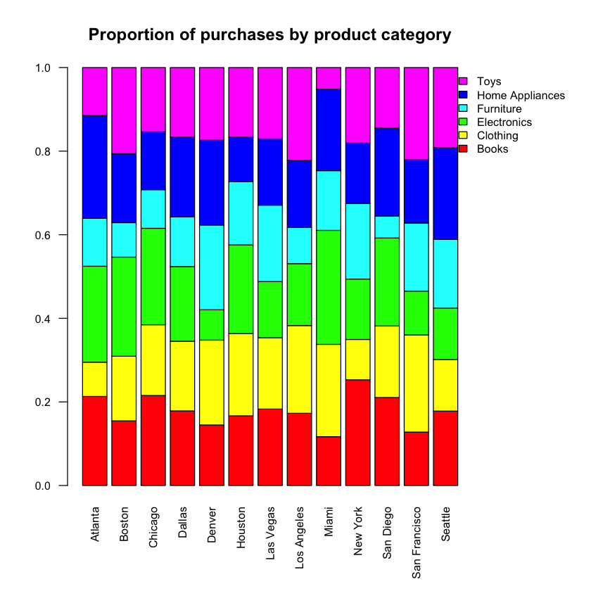

```r
# Contingency table of product categories and store locations.
product_store_cross_tab = xtabs(~sales_data$Product_Category+sales_data$Store_Location)

# Proportion table.
proportion_data <- prop.table(product_store_cross_tab, margin = 2)

# Stacked bar plot.
par(mar = c(6, 4, 4, 7))
barplot(proportion_data,
        main="Proportion of purchases by product category",
        col = rainbow(nrow(proportion_data)),
        legend.text = rownames(proportion_data),
        args.legend = list(x = "topright", inset = c(-0.25, 0), bty = "n", cex = 0.8),
        cex.names = 0.8,
        cex.axis = 0.8,
        las = 2)
```

**2b) What Product_Category accounts for the lowest cumulative purchase amount (use values in "Purchase_Amount")?** (1 point)

```r
# Total sales by category.
total_sales_by_category <- aggregate(Purchase_Amount ~ Product_Category, data = sales_data, sum)

total_sales_by_category[order(total_sales_by_category$Purchase_Amount), ]
```

A data.frame: 6 × 2

|  | Product_Category <fct> | Purchase_Amount <dbl> |
| --- | --- | --- |
| 4 | Furniture | 122478.6 |
| 2 | Clothing | 167241.9 |
| 3 | Electronics | 168118.5 |
| 6 | Toys | 168765.4 |
| 5 | Home Appliances | 180004.2 |
| 1 | Books | 185993.8 |

Response:

Furniture accounts for the lowest cumulative purchases across all stores.

**2c) Which Store_Location has the highest proportion of furniture purchases? The proportion should be based on number of purchases, not on purchase amount.** (1 point)

```r
# Furniture percentages in each store location.
furniture_proportions <- proportion_data["Furniture", ]

sort(furniture_proportions, decreasing = TRUE)
```

**Denver**

0.202898550724638

**Las Vegas**

0.182926829268293

**New York**

0.180722891566265

**Seattle**

0.164383561643836

**San Francisco**

0.162790697674419

**Houston**

0.151515151515152

**Miami**

0.142857142857143

**Dallas**

0.119047619047619

**Atlanta**

0.114754098360656

**Chicago**

0.0923076923076923

**Los Angeles**

0.0864197530864197

**Boston**

0.0824742268041237

**San Diego**

0.0526315789473684

Response:

Denver has the largest proportion of furniture purchases.

**2d) Which Store_Location has the lowest total purchases (use amounts in "Purchase_Amount")?** (1 point)

```r
total_sales_by_store <- aggregate(Purchase_Amount ~ Store_Location, data = sales_data, sum)

total_sales_by_store[order(total_sales_by_store$Purchase_Amount), ]
```

A data.frame: 13 × 2

|  | Store_Location <fct> | Purchase_Amount <dbl> |
| --- | --- | --- |
| 1 | Atlanta | 56866.20 |
| 5 | Denver | 59561.84 |
| 3 | Chicago | 63450.57 |
| 6 | Houston | 64143.81 |
| 11 | San Diego | 69391.38 |
| 9 | Miami | 74986.82 |
| 7 | Las Vegas | 80970.01 |
| 13 | Seattle | 81080.27 |
| 10 | New York | 81236.03 |
| 12 | San Francisco | 82676.94 |
| 4 | Dallas | 88589.63 |
| 8 | Los Angeles | 90356.77 |
| 2 | Boston | 99292.07 |

Response:

Atlanta has the lowest total purchases.

**2e) Unfortunately, let's imagine that management has decided to close the Denver store location and also stop selling furniture across all store locations. Create a new dataframe called "filtered_sales_data", where rows that contain "Denver" in "Store_Location" or "Furniture" in "Product_Category" are removed. The resulting dataframe must have 812 observation rows and 8 variables. Sort filtered_sales_data by Customer_ID in descending order and print rows 150 to 160 of the resulting dataframe.** (3 points)

```r
# Assuming your original dataframe is called sales_data

# Filter out rows where Store_Location is "Denver" or Product_Category is "Furniture"
filtered_sales_data <- sales_data[!(sales_data$Store_Location == "Denver" | sales_data$Product_Category == "Furniture"), ]

# Check the number of rows to ensure it has 812 rows
if (nrow(filtered_sales_data) == 812) {
  # Sort the dataframe by Customer_ID in descending order
  filtered_sales_data <- filtered_sales_data[order(filtered_sales_data$Customer_ID, decreasing = TRUE), ]

  # Print rows 150 to 160
  print(filtered_sales_data[150:160, ])
} else {
  print(paste("The resulting dataframe does not have 812 rows, it has", nrow(filtered_sales_data), "rows."))
}
```

```
    Customer_ID Product_Category Purchase_Amount Purchase_Date Customer_Age
817         920      Electronics         1044.86    2024-01-12           30
816         919             Toys           39.67    2024-05-14           40
814         918  Home Appliances         1554.56    2024-03-21           40
810         916            Books           41.64    2024-05-28           27
813         916             Toys          848.26    2024-07-24           27
811         916      Electronics           10.16    2024-07-18           27
808         915  Home Appliances          191.35    2024-07-16           26
809         915            Books         1613.36    2024-05-28           26
807         913            Books         1227.82    2024-05-24           46
806         911            Books          638.48    2024-11-25           63
805         907      Electronics          514.34    2024-10-27           39
    Customer_Gender Store_Location Satisfaction_Score
817          Female        Atlanta           8.839395
816          Female        Houston           4.695880
814          Female    Los Angeles           7.357079
810            Male         Boston           4.577198
813            Male        Seattle           6.211545
811            Male        Chicago           7.610019
808          Female        Atlanta           6.162825
809          Female        Houston           8.126733
807          Female        Seattle           8.544366
806            Male         Boston           6.327873
805            Male        Chicago           9.019206
```

# Question 3: Exploratory Data Analysis (8 points)

**We will be using the split data sets, "train_sales_data" and "test_sales_data," creating in the starter code in the beginning of this document going forward.**

**3a) Using "train_sales_data", create an Hexbin Plot of the response, "Satisfaction_Score" against "Purchase_Amount". Calculate then output the R-squared and comment on the direction (positive or negative) and strength of the correlation (<=0.3: weak; >0.3 and <0.7: moderate; >=0.7: strong).** (5 points)

```
[1] "R-squared for Satisfaction_Score vs Purchase_Amount: 0.132"
[1] "The correlation between Satisfaction_Score and Purchase_Amount is positive and the strength of the correlation is weak ."
```

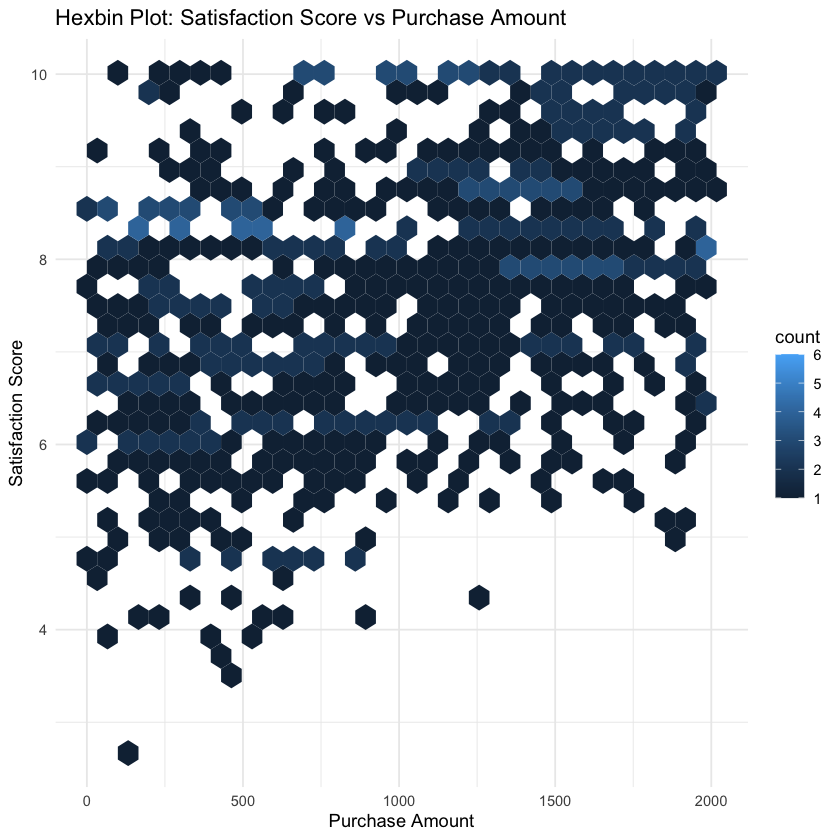

```r
# Hexbin plot for Satisfaction_Score vs Purchase_Amount
hexbin_plot <- ggplot(train_sales_data, aes(x = Purchase_Amount, y = Satisfaction_Score)) +
  geom_hex(bins = 30) +
  labs(title = "Hexbin Plot: Satisfaction Score vs Purchase Amount", x = "Purchase Amount", y = "Satisfaction Score") +
  theme_minimal()

# Print the Hexbin plot
print(hexbin_plot)

# Calculate R-squared for Satisfaction_Score vs Purchase_Amount
model <- lm(Satisfaction_Score ~ Purchase_Amount, data = train_sales_data)
r_squared <- summary(model)$r.squared

# Output the R-squared value
print(paste("R-squared for Satisfaction_Score vs Purchase_Amount:", round(r_squared, 3)))

# Comment on the direction and strength of the correlation
if (r_squared <= 0.3) {
  strength <- "weak"
} else if (r_squared > 0.3 & r_squared < 0.7) {
  strength <- "moderate"
} else {
  strength <- "strong"
}

direction <- ifelse(coef(model)[2] > 0, "positive", "negative")

print(paste("The correlation between Satisfaction_Score and Purchase_Amount is", direction, "and the strength of the correlation is", strength, "."))
```

**3b)Using "train_sales_data", create a boxplot of the response, Satisfaction_Score, vs. Purchase_Month. You will have to calculate Purchase_Month by using Purchase_Date. Ensure Purchase_Month is a categorical variable and ranges from 01 - 12. From observation of the boxplot, what month has the highest median satisfaction score? Using just the resulting boxplot, is the satisfaction score for any of the month significantly different from the satisfaction scores of the other months? Note: we will now have 9 variables (since we added Purchase_Month) in the resulting train and test dataframes** (3 points)

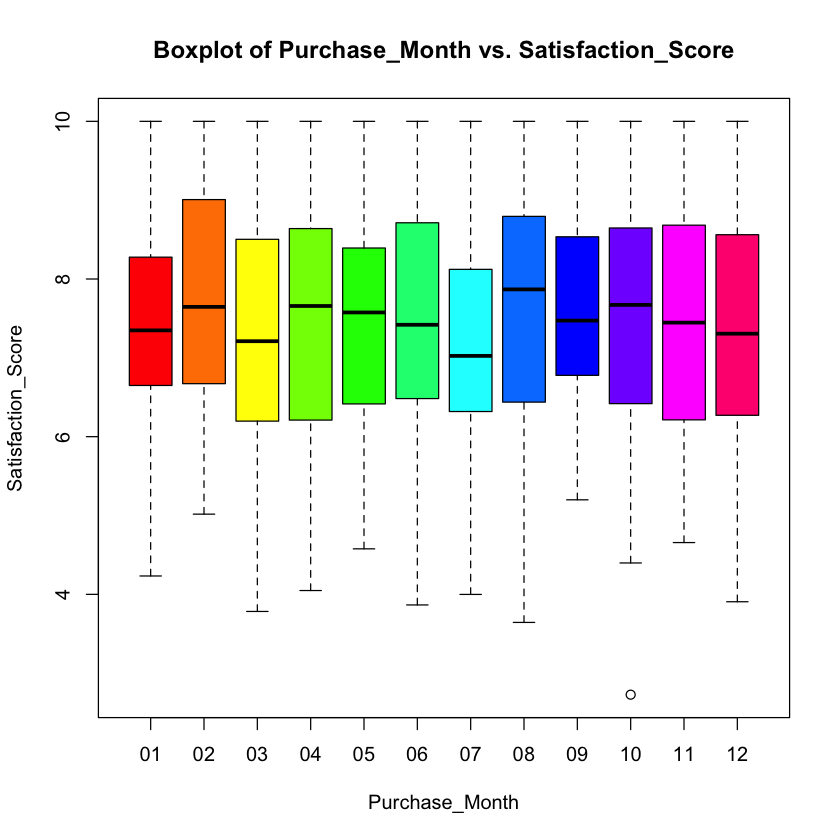

```r
# Column for month of purchase.
train_sales_data$Purchase_Month <- format(train_sales_data$Purchase_Date, "%m")
train_sales_data$Purchase_Month=as.factor(train_sales_data$Purchase_Month)

# Boxplot.
boxplot(Satisfaction_Score ~ Purchase_Month, data = train_sales_data,
        xlab = "Purchase_Month",
        ylab = "Satisfaction_Score",
        main = "Boxplot of Purchase_Month vs. Satisfaction_Score",
        col = rainbow(length(unique(train_sales_data$Purchase_Month))))
```

Response:

August, i.e. month 8, has the highest median Satisfaction_Score. The boxplots all overlap each other. We cannot determine if the satisfaction scores of any month are significantly different from the the satisfaction scores of the other months.

# Question 4: Multiple Linear Regression (15 points)

**4a) Using train_sales_data, create a multiple linear regression model and call it "model1" with Satisfaction_Score as the response then Product_Category, Purchase_Amount, Customer_Age, Customer_Gender, Store_Location, and Purchase_Month as the predictors. Print the model summary. Is the model of any use in predicting Satisfaction_Score? using α = 0.05, provide the following elements of the test of overall regression of the model: null hypothesis H0, alternative hypothesis Ha, F-statistic or p-value, and conclusion** (3 points)

```r
model1 <- lm(Satisfaction_Score ~ Product_Category + Purchase_Amount + Customer_Age + Customer_Gender
             + Store_Location + Purchase_Month, data = train_sales_data)
summary(model1)
```

```
Call:
lm(formula = Satisfaction_Score ~ Product_Category + Purchase_Amount +
    Customer_Age + Customer_Gender + Store_Location + Purchase_Month,
    data = train_sales_data)

Residuals:
    Min      1Q  Median      3Q     Max
-2.9013 -0.6519 -0.0141  0.6243  3.2332

Coefficients:
                                  Estimate Std. Error t value Pr(>|t|)
(Intercept)                      6.180e+00  2.125e-01  29.086  < 2e-16 ***
Product_CategoryClothing        -3.004e-02  1.151e-01  -0.261   0.7942
Product_CategoryElectronics      1.939e+00  1.153e-01  16.818  < 2e-16 ***
Product_CategoryFurniture        9.941e-01  1.241e-01   8.010 4.27e-15 ***
Product_CategoryHome Appliances  8.500e-01  1.148e-01   7.401 3.54e-13 ***
Product_CategoryToys            -9.957e-01  1.153e-01  -8.634  < 2e-16 ***
Purchase_Amount                  1.031e-03  6.144e-05  16.784  < 2e-16 ***
Customer_Age                    -1.699e-03  2.457e-03  -0.691   0.4895
Customer_GenderMale             -3.552e-02  6.956e-02  -0.511   0.6098
Store_LocationBoston            -1.588e-01  1.803e-01  -0.881   0.3786
Store_LocationChicago           -7.093e-03  1.951e-01  -0.036   0.9710
Store_LocationDallas            -1.870e-01  1.870e-01  -1.000   0.3176
Store_LocationDenver            -1.812e-01  1.927e-01  -0.940   0.3474
Store_LocationHouston           -1.103e-01  1.949e-01  -0.566   0.5717
Store_LocationLas Vegas         -1.725e-01  1.839e-01  -0.938   0.3485
Store_LocationLos Angeles       -1.341e-01  1.870e-01  -0.717   0.4735
Store_LocationMiami             -1.685e-01  1.901e-01  -0.886   0.3757
Store_LocationNew York          -6.727e-02  1.869e-01  -0.360   0.7190
Store_LocationSan Diego         -3.251e-01  1.912e-01  -1.701   0.0894 .
Store_LocationSan Francisco     -3.385e-01  1.835e-01  -1.845   0.0654 .
Store_LocationSeattle           -1.570e-02  1.893e-01  -0.083   0.9339
Purchase_Month02                 1.802e-01  1.655e-01   1.089   0.2763
Purchase_Month03                -9.526e-02  1.590e-01  -0.599   0.5492
Purchase_Month04                 1.529e-01  1.747e-01   0.875   0.3817
Purchase_Month05                -3.615e-02  1.592e-01  -0.227   0.8204
Purchase_Month06                -1.521e-02  1.563e-01  -0.097   0.9225
Purchase_Month07                 6.859e-04  1.521e-01   0.005   0.9964
Purchase_Month08                 1.928e-01  1.574e-01   1.225   0.2211
Purchase_Month09                 9.427e-02  1.603e-01   0.588   0.5567
Purchase_Month10                 1.315e-01  1.598e-01   0.822   0.4111
Purchase_Month11                -2.318e-02  1.572e-01  -0.147   0.8828
Purchase_Month12                 5.099e-02  1.610e-01   0.317   0.7515
---
Signif. codes:  0 ‘***’ 0.001 ‘**’ 0.01 ‘*’ 0.05 ‘.’ 0.1 ‘ ’ 1

Residual standard error: 0.9507 on 768 degrees of freedom
Multiple R-squared:  0.5737,	Adjusted R-squared:  0.5565
F-statistic: 33.34 on 31 and 768 DF,  p-value: < 2.2e-16
```

**4b) Using α = 0.05, which of the estimated coefficients are statistically significant in model1** (2 points)

Response:

Using α = 0.05, the estimated coefficients for the Intercept, Product_CategoryElectronics, Product_CategoryFurniture, Product_CategoryHome Appliances, Product_CategoryToys, Purchase_Amount are statistically significant in model1.

**4c) What is the interpretation of the intercept coefficient with respect to the satisfaction score? In other words, what does the intercept represent for this particular model** (2 points)

Response:

**4d) What is the interpretation of the Purchase_Amount coefficient?** (2 points)

Response:

The satisfaction score increases by 1.031e-03 points for a one unit increase in the purchase amount while holding all other predictors constant. In other words, for the base case (Product_Category = Books; Customer_Gender = Female; Store_Location = Atlanta; Purchase_Month = 01 (January)), the satisfaction score will increase 1.031e-03 points for a one unit increase in Purchase_Amount while holding Customer_Age constant.

**4e) Create scatter plots of the standardized residuals of model1 vs. the quantitative predictors (Purchase_Amount, Customer_Age). Using these plots, does the linearity assumption hold for these predictors?** (2 points)

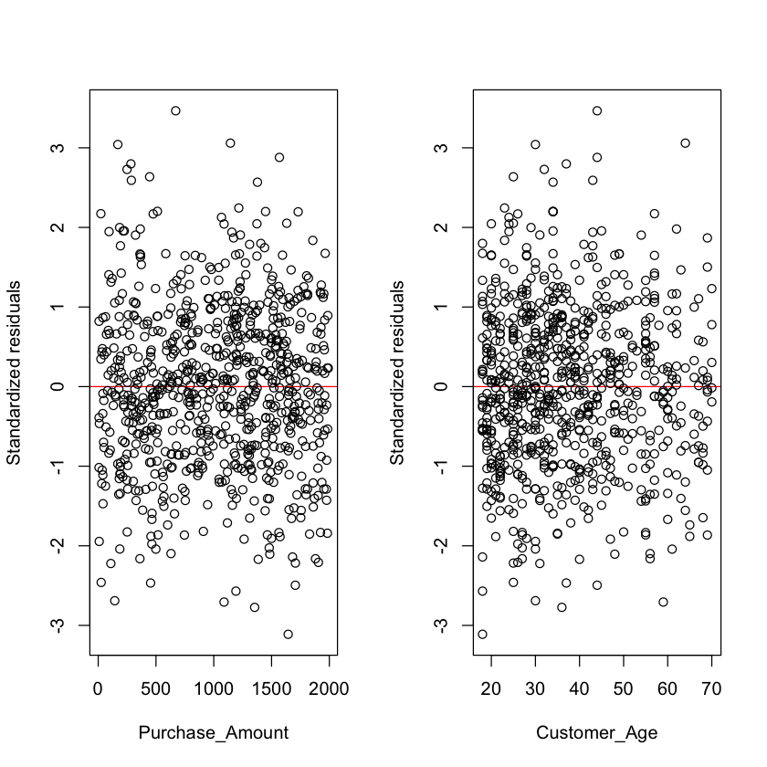

```r
model1_sresids <- rstandard(model1)
par(mfrow = c(1, 2))
plot(train_sales_data$Purchase_Amount, model1_sresids,
     xlab = "Purchase_Amount",
     ylab = "Standardized residuals",
     abline(h=0, col = "red")
     )
plot(train_sales_data$Customer_Age, model1_sresids,
     xlab = "Customer_Age",
     ylab = "Standardized residuals",
     abline(h=0, col = "red")
     )
```

Response:

When assessing linearity assumptions, we examine the standardized residuals (i.e., the differences between observed and predicted values) in a regression model. The residual plot helps us identify patterns or deviations from linearity. If the relationship between predictors and the response is linear, we expect the residuals to be randomly scattered around zero. Non-random patterns (e.g., U-shaped, funnel-shaped, or curvilinear) in the residual plot suggest violations of linearity assumptions. Hence, for the plots we have created above, the linearity assumption appears to hold for Purchase_Amount and Customer_Age as the residuals are randomly scattered about the horizontal axis.

**4f) Create a scatterplot of the standardized residuals vs. the fitted values of model1. Does the constant variance assumption hold? Does the assumption of uncorrelated errors hold?** (2 points)

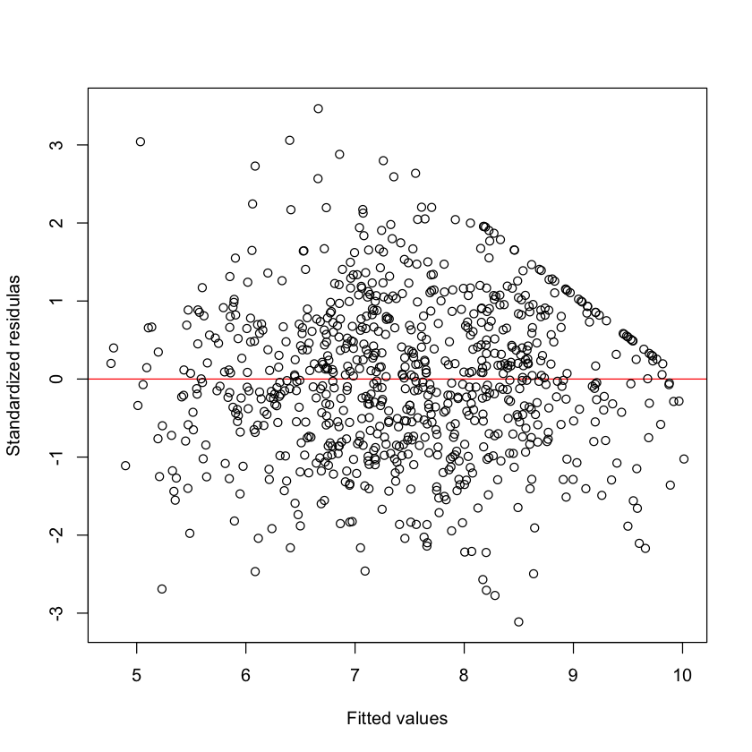

```r
plot(model1$fitted.values, model1_sresids,
     xlab = "Fitted values",
     ylab = "Standardized residulas",
     abline(h=0, col = "red")
     )
```

Response:

The residuals vs. fitted values plot is a useful tool for assessing both the constant variance assumption and the independence assumption in regression models. For the constant variance assumption, also known as homoscedasticity, this assumption states that the spread of the residuals (i.e., the differences between observed and predicted values) should be roughly equal across all levels of the fitted values. In the residuals vs. fitted values plot, if the spread of residuals remains consistent as the fitted values change, the constant variance assumption is met. Otherwise, if the spread systematically increases or decreases, the assumption may be violated. Hence, for the plot we have created above, the assumption of constant variance appears to not hold as we do see a slight decrease in variance of the standardized residuals as we move to the higher fitted values.

We also use the plot to check that the residuals are independent of each other (i.e., not correlated). Patterns (e.g., U-shape, funnel shape) may indicate a violation of the assumption. Keep in mind the assumption is independence, but we cannot directly prove independence. We check for correlated errors (residuals) instead. If there are clumps in the residual plot, then there is evidence of correlated errors. If you have correlated errors, you cannot assume independence. If you do not see clumping, then you can say that the errors are not correlated. However, this is a necessary, but not sufficient, condition for independence. We can argue for a lack of independence, but the best we can say in the converse situation is that the errors are uncorrelated and that independence is possible.

Hence, based on the plot, the assumption of uncorrelated errors appear to hold as we do not see any clustering or clumping in the plot.

**4g) Create a histogram and normal QQ plot of the standardized residuals. A 95% pointwise confidence envelope must be used for the QQ plot. Does the assumption of normality hold?** (2 points)

1. 639

2. 627

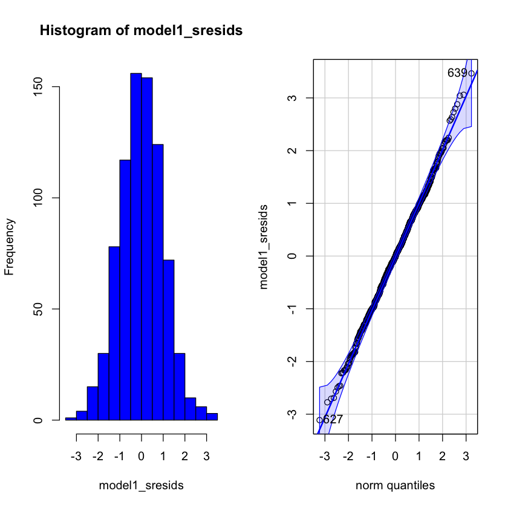

```r
# QQ plot.
par(mfrow = c(1, 2))
hist(model1_sresids, col = "blue")
qqPlot(model1_sresids, envelope = 0.95)
```

Response:

The histogram of the standardized residuals appears to be symmetrical as we would expect in a normal distribution. All of the points fall within the 95% confidence interval on the QQ plot, also indicating the data follows a normal distribution.

# 5) Multi-collinearity and Outliers (9 points)

**5a) Calculate the VIF of each predictor in model1. Using a VIF threshold of $max(10, 1/(1-R^{2}))$ what conclusion do you make regarding multicolinearity?** (2 points)

```r
# VIF threshold.
cat("VIF threshold: ", max(10, 1/(1-summary(model1)$r.squared)), "\n")

# VIF.
vif(model1)
```

```
VIF threshold:  10
```

A matrix: 6 × 3 of type dbl

|  | GVIF | Df | GVIF^(1/(2*Df)) |
| --- | --- | --- | --- |
| Product_Category | 1.194839 | 5 | 1.017961 |
| Purchase_Amount | 1.051836 | 1 | 1.025591 |
| Customer_Age | 1.038019 | 1 | 1.018832 |
| Customer_Gender | 1.030120 | 1 | 1.014948 |
| Store_Location | 1.322333 | 12 | 1.011710 |
| Purchase_Month | 1.292112 | 11 | 1.011717 |

Response:

The VIFs for the predictors are less than the threshold of 10, suggesting multi-collinearity is not present in model1.

**5b) Create a plot of Cook's distances for model1. Using a threshold of 4/n, print the calculated threshold. Are there any outliers present? How many outliers do we have? Output the highest 5 outlier rows from train_sales_data (since we used train_sales_data to create model1).** (5 points)

```
[1] "Cook's distance threshold: 0.005"
[1] "Number of outliers: 45"
    Customer_ID Product_Category Purchase_Amount Purchase_Date Customer_Age
120         963             Toys         1143.95    2024-04-07           64
639         898            Books          670.47    2024-11-26           44
216         535             Toys          169.82    2024-12-15           30
91          444             Toys         1567.93    2024-10-24           44
627         317  Home Appliances         1643.77    2024-11-06           18
    Customer_Gender Store_Location Satisfaction_Score Purchase_Month
120          Female        Chicago           9.236591             04
639          Female        Houston           9.896602             11
216          Female      San Diego           7.862578             12
91           Female        Atlanta           9.531038             10
627          Female      Las Vegas           5.597841             11
```

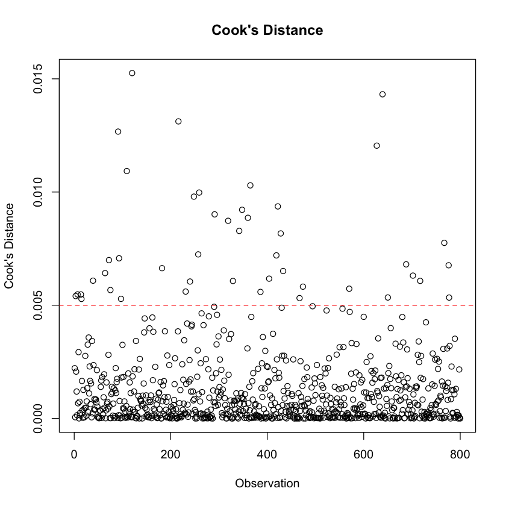

```r
# Calculate Cook's distances
model1_cook <- cooks.distance(model1)

# Get the number of rows in the dataset used to create the model
cook_n <- nrow(model1$model)

# Calculate threshold
cook_threshold <- 4 / cook_n

# Plot Cook's distances
plot(model1_cook, main = "Cook's Distance", ylab = "Cook's Distance", xlab = "Observation")
abline(h = cook_threshold, col = "red", lty = 2)

# Print the calculated threshold
print(paste("Cook's distance threshold:", cook_threshold))

# Identify outliers
outliers <- which(model1_cook > cook_threshold)

# Print the number of outliers
print(paste("Number of outliers:", length(outliers)))

# Output the highest 5 outlier rows from train_sales_data
highest_outliers <- order(model1_cook[outliers], decreasing = TRUE)[1:5]
outlier_rows <- train_sales_data[outliers[highest_outliers], ]
print(outlier_rows)
```

**5c) Create a new dataframe from train_sales_data and call it train_sales_data_cook. This dataframe should exclude the outliers identified in Question (5b) above. Sort the dataframe by Purchase_Amount in descending order and print the first 5 rows. Note: the sorting should be permanently (not temporarily) stored unless otherwise stated.** (2 points)

```r
# Create a new dataframe excluding the outliers
train_sales_data_cook <- train_sales_data[-outliers, ]

# Sort the dataframe by Purchase_Amount in descending order
train_sales_data_cook <- train_sales_data_cook[order(-train_sales_data_cook$Purchase_Amount), ]

# Print the first 5 rows
print(head(train_sales_data_cook, 5))
```

```
    Customer_ID Product_Category Purchase_Amount Purchase_Date Customer_Age
792         326      Electronics         1990.98    2024-11-11           28
406         153         Clothing         1986.71    2024-11-06           19
449         759            Books         1984.87    2024-05-31           31
279         804            Books         1983.22    2024-05-23           35
745        1015  Home Appliances         1982.30    2024-03-18           64
    Customer_Gender Store_Location Satisfaction_Score Purchase_Month
792            Male  San Francisco           9.943278             11
406            Male    Los Angeles           8.805514             11
449            Male        Chicago           7.599500             05
279            Male        Houston           6.268766             05
745            Male    Los Angeles           8.918352             03
```

# 6) Subsets of Coefficients (6 points)

**6a) Calculate the 95% confidence interval for the regression coefficient of Customer_Age in model1. What can you conclude from the 95% confidence interval for the Customer_Age coefficient?** (1 point)

```r
confint(model1, "Customer_Age", level = 0.95)
```

A matrix: 1 × 2 of type dbl

|  | 2.5 % | 97.5 % |
| --- | --- | --- |
| Customer_Age | -0.006521375 | 0.003124306 |

Response:

Since the 95% confidence interval for the Customer_Age coefficient includes 0, it means that there is not enough evidence to conclude that Customer_Age has a statistically significant effect on Satisfaction_Score at the 5% significance level given the other predictors in the model. In other words, the effect of Customer_Age on the dependent variable could be zero given the other predictors in the model and any observed effect could be due to random chance rather than a true underlying relationship.

**6b) Using train_sales_data, create a new model and call it “model_no_age” with the same response and predictors as “model1”, but without the predictor Customer_Age. Print the model summary.** (1 point)

```r
model_no_age <- lm(Satisfaction_Score ~ Product_Category + Purchase_Amount + Customer_Gender
             + Store_Location + Purchase_Month, data = train_sales_data)
summary(model_no_age)
```

```
Call:
lm(formula = Satisfaction_Score ~ Product_Category + Purchase_Amount +
    Customer_Gender + Store_Location + Purchase_Month, data = train_sales_data)

Residuals:
    Min      1Q  Median      3Q     Max
-2.8707 -0.6461 -0.0067  0.6370  3.2177

Coefficients:
                                  Estimate Std. Error t value Pr(>|t|)
(Intercept)                      6.117e+00  1.917e-01  31.908  < 2e-16 ***
Product_CategoryClothing        -2.581e-02  1.149e-01  -0.225   0.8224
Product_CategoryElectronics      1.938e+00  1.152e-01  16.817  < 2e-16 ***
Product_CategoryFurniture        9.924e-01  1.241e-01   8.000 4.57e-15 ***
Product_CategoryHome Appliances  8.485e-01  1.148e-01   7.392 3.78e-13 ***
Product_CategoryToys            -9.946e-01  1.153e-01  -8.629  < 2e-16 ***
Purchase_Amount                  1.029e-03  6.136e-05  16.776  < 2e-16 ***
Customer_GenderMale             -3.701e-02  6.950e-02  -0.532   0.5946
Store_LocationBoston            -1.545e-01  1.801e-01  -0.858   0.3912
Store_LocationChicago           -7.759e-03  1.950e-01  -0.040   0.9683
Store_LocationDallas            -1.800e-01  1.866e-01  -0.965   0.3350
Store_LocationDenver            -1.821e-01  1.926e-01  -0.946   0.3447
Store_LocationHouston           -1.108e-01  1.948e-01  -0.569   0.5696
Store_LocationLas Vegas         -1.716e-01  1.838e-01  -0.933   0.3510
Store_LocationLos Angeles       -1.335e-01  1.870e-01  -0.714   0.4756
Store_LocationMiami             -1.718e-01  1.899e-01  -0.905   0.3659
Store_LocationNew York          -6.693e-02  1.869e-01  -0.358   0.7203
Store_LocationSan Diego         -3.242e-01  1.911e-01  -1.697   0.0902 .
Store_LocationSan Francisco     -3.394e-01  1.834e-01  -1.851   0.0646 .
Store_LocationSeattle           -1.054e-02  1.891e-01  -0.056   0.9556
Purchase_Month02                 1.794e-01  1.654e-01   1.085   0.2784
Purchase_Month03                -9.928e-02  1.588e-01  -0.625   0.5320
Purchase_Month04                 1.500e-01  1.746e-01   0.859   0.3905
Purchase_Month05                -3.265e-02  1.591e-01  -0.205   0.8374
Purchase_Month06                -9.799e-03  1.560e-01  -0.063   0.9499
Purchase_Month07                 1.962e-03  1.521e-01   0.013   0.9897
Purchase_Month08                 1.932e-01  1.574e-01   1.228   0.2200
Purchase_Month09                 9.164e-02  1.602e-01   0.572   0.5676
Purchase_Month10                 1.334e-01  1.597e-01   0.835   0.4038
Purchase_Month11                -1.730e-02  1.569e-01  -0.110   0.9122
Purchase_Month12                 5.058e-02  1.609e-01   0.314   0.7533
---
Signif. codes:  0 ‘***’ 0.001 ‘**’ 0.01 ‘*’ 0.05 ‘.’ 0.1 ‘ ’ 1

Residual standard error: 0.9503 on 769 degrees of freedom
Multiple R-squared:  0.5734,	Adjusted R-squared:  0.5568
F-statistic: 34.45 on 30 and 769 DF,  p-value: < 2.2e-16
```

**6c) Perform a partial F-test between model_no_age and model1. What is the F-value and the corresponding p-value of the test? What is your interpretation of the test (use an alpha level of 0.05 when evaluating the p-value)?** (3 points)

```r
# Using anova(reduced model, full model) to perform partial F-test
partial_f_test <- anova(model_no_age, model1)

# Extract the F-value and p-value
f_value <- partial_f_test$`F`[2]
p_value <- partial_f_test$`Pr(>F)`[2]

# Print the F-value and p-value
print(paste("F-value:", f_value))
print(paste("p-value:", p_value))
```

```
[1] "F-value: 0.477979224417939"
[1] "p-value: 0.489547999985173"
```

Response:

Since the p-value from the partial F-test is greater than the alpha level of 0.05, it means that the additional predictor (Customer_Age) in model1 does not significantly improve the model compared to model_no_age. In other words, there is not enough evidence to reject the null hypothesis, which states that the simpler model (model_no_age) is sufficient and the additional predictor (Customer_Age) in model1 does not provide a statistically significant improvement.

**6d) Using the dataset created in Question (5c) after our outlier analysis i.e. train_sales_data_cook, create a new model and call it "model_outlier", with Satisfaction_Score as the response and Product_Category, Purchase_Amount, Customer_Gender, Store_Location and Purchase_Month as the predictors (note that we are excluding Customer_Age compared to model1). Print the model summary.** (1 point)

```r
model_outlier <- lm(Satisfaction_Score ~ Product_Category + Purchase_Amount + Customer_Gender
             + Store_Location + Purchase_Month, data = train_sales_data_cook)
summary(model_outlier)
```

```
Call:
lm(formula = Satisfaction_Score ~ Product_Category + Purchase_Amount +
    Customer_Gender + Store_Location + Purchase_Month, data = train_sales_data_cook)

Residuals:
    Min      1Q  Median      3Q     Max
-1.8670 -0.5861  0.0007  0.6096  1.9057

Coefficients:
                                  Estimate Std. Error t value Pr(>|t|)
(Intercept)                      5.867e+00  1.714e-01  34.226   <2e-16 ***
Product_CategoryClothing        -3.039e-02  1.001e-01  -0.304   0.7616
Product_CategoryElectronics      1.958e+00  9.983e-02  19.608   <2e-16 ***
Product_CategoryFurniture        9.610e-01  1.095e-01   8.773   <2e-16 ***
Product_CategoryHome Appliances  9.412e-01  9.984e-02   9.427   <2e-16 ***
Product_CategoryToys            -1.075e+00  1.004e-01 -10.703   <2e-16 ***
Purchase_Amount                  1.088e-03  5.363e-05  20.289   <2e-16 ***
Customer_GenderMale             -6.094e-03  6.055e-02  -0.101   0.9199
Store_LocationBoston            -3.230e-02  1.603e-01  -0.201   0.8404
Store_LocationChicago            1.237e-01  1.762e-01   0.702   0.4829
Store_LocationDallas            -3.200e-02  1.653e-01  -0.194   0.8466
Store_LocationDenver            -7.416e-03  1.747e-01  -0.042   0.9662
Store_LocationHouston            1.921e-02  1.744e-01   0.110   0.9123
Store_LocationLas Vegas          2.335e-03  1.640e-01   0.014   0.9886
Store_LocationLos Angeles       -2.673e-02  1.679e-01  -0.159   0.8735
Store_LocationMiami             -7.738e-02  1.695e-01  -0.456   0.6482
Store_LocationNew York           1.018e-01  1.667e-01   0.611   0.5414
Store_LocationSan Diego         -2.129e-01  1.696e-01  -1.255   0.2098
Store_LocationSan Francisco     -2.020e-01  1.633e-01  -1.237   0.2166
Store_LocationSeattle            7.560e-02  1.676e-01   0.451   0.6521
Purchase_Month02                 2.530e-01  1.473e-01   1.717   0.0863 .
Purchase_Month03                -7.990e-02  1.381e-01  -0.578   0.5631
Purchase_Month04                 1.927e-01  1.560e-01   1.236   0.2170
Purchase_Month05                 3.928e-02  1.366e-01   0.288   0.7738
Purchase_Month06                -1.773e-02  1.361e-01  -0.130   0.8963
Purchase_Month07                 4.874e-02  1.313e-01   0.371   0.7106
Purchase_Month08                 2.817e-01  1.354e-01   2.081   0.0378 *
Purchase_Month09                 1.508e-01  1.371e-01   1.100   0.2718
Purchase_Month10                 2.762e-01  1.412e-01   1.956   0.0508 .
Purchase_Month11                -5.573e-03  1.371e-01  -0.041   0.9676
Purchase_Month12                 6.727e-02  1.411e-01   0.477   0.6337
---
Signif. codes:  0 ‘***’ 0.001 ‘**’ 0.01 ‘*’ 0.05 ‘.’ 0.1 ‘ ’ 1

Residual standard error: 0.805 on 724 degrees of freedom
Multiple R-squared:  0.6727,	Adjusted R-squared:  0.6591
F-statistic:  49.6 on 30 and 724 DF,  p-value: < 2.2e-16
```

# 7) Prediction (5 points)

**7a) Use model1, model_no_age, and model_outlier to predict the Satisfaction_Score for each row in test_sales_data. Calculate and output the mean squared prediction error (MSPE) for each model's predictions. You will have to add Purchase_Month to test_sales_data as you did to train_sales_data. Which model has the lower MSPE?** (2 points)

```r
# Add Purchase_month to test_sales_data.
test_sales_data$Purchase_Month <- format(test_sales_data$Purchase_Date, "%m")
test_sales_data$Purchase_Month=as.factor(test_sales_data$Purchase_Month)

# Predict Satisfaction_Score using model1
predictions_model1 <- predict(model1, newdata = test_sales_data)

# Predict Satisfaction_Score using model_no_age
predictions_model_no_age <- predict(model_no_age, newdata = test_sales_data)

# Predict Satisfaction_Score using model_outlier
predictions_model_outlier <- predict(model_outlier, newdata = test_sales_data)

# Calculate MSPE for model1
mspe_model1 <- mean((test_sales_data$Satisfaction_Score - predictions_model1)^2)

# Calculate MSPE for model_no_age
mspe_model_no_age <- mean((test_sales_data$Satisfaction_Score - predictions_model_no_age)^2)

# Calculate MSPE for model_outlier
mspe_model_outlier <- mean((test_sales_data$Satisfaction_Score - predictions_model_outlier)^2)

# Output the MSPE for each model
print(paste("MSPE for model1:", mspe_model1))
print(paste("MSPE for model_no_age:", mspe_model_no_age))
print(paste("MSPE for model_outlier:", mspe_model_outlier))
```

```
[1] "MSPE for model1: 0.894228121043423"
[1] "MSPE for model_no_age: 0.890872069242706"
[1] "MSPE for model_outlier: 0.901003358560059"
```

Response:

- The MSPEs for model1 and model_no_age are very close, which makes sense, since the models only differ by a single predictor, Customer_Age.
- model_no_age, which excludes the Customer_Age variable, has the lowest mean squared prediction error (MSPE).
- Interestingly enough, the mean squared prediction error (MSPE) for the model where we removed the outliers is the highest (although it is just slightly higher than the other two).

**7b) Print the Adjusted R-squared for model1, model_no_age, and model_outlier? Comment on what you observed considering what you also observed from the mean squared prediction error (MSPE) from Question (7a)** (1 point)

```r
# Print Adjusted R-squared for model1
adj_r2_model1 <- summary(model1)$adj.r.squared
print(paste("Adjusted R-squared for model1:", adj_r2_model1))

# Print Adjusted R-squared for model_no_age
adj_r2_model_no_age <- summary(model_no_age)$adj.r.squared
print(paste("Adjusted R-squared for model_no_age:", adj_r2_model_no_age))

# Print Adjusted R-squared for model_outlier
adj_r2_model_outlier <- summary(model_outlier)$adj.r.squared
print(paste("Adjusted R-squared for model_outlier:", adj_r2_model_outlier))
```

```
[1] "Adjusted R-squared for model1: 0.556461274972012"
[1] "Adjusted R-squared for model_no_age: 0.556762362656329"
[1] "Adjusted R-squared for model_outlier: 0.659140844053452"
```

Response:

**Model_no_age**:

- Lowest MSPE: The lower MSPE on the test dataset suggests that removing the Customer_Age variable has improved the model’s predictive accuracy. This could mean that Customer_Age was not a strong predictor, or its inclusion added noise to the model.
- Slight Improvement in Adjusted R-squared: The slight improvement in Adjusted R-squared on the train dataset suggests that the remaining predictors are sufficient to explain the variance in the dependent variable.

**7c) Suppose there is a purchase with the following data: Product_Category: Electronics; Purchase_Amount: 574.99; Customer_Gender: Female; Customer_Age: 39; Store_Location: San Francisco; Purchase_Month: 06. Use model1 to predict the Satisfaction_Score of the purchase with a 95% prediction interval. What is the interpretation of this interval?** (2 points)

```r
# New data.
new_purchase <- data.frame(Product_Category="Electronics", Purchase_Amount=574.99, Customer_Gender="Female",
                           Customer_Age=39, Store_Location="San Francisco", Purchase_Month="06")

# Prediction interval.
predict(model1, new_purchase, interval = "prediction", level = 0.95)
```

A matrix: 1 × 3 of type dbl

|  | fit | lwr | upr |
| --- | --- | --- | --- |
| 1 | 8.292103 | 6.392664 | 10.19154 |

Response:

This means that the predicted Satisfaction_Score is 8.292103, and we are 95% confident that the actual Satisfaction_Score will fall between 6.392664 and 10.19154 .

# 8 Alternate Qualitative Pre-processing (2 points)

**Write (with explanations) separate R codes where model.matrix() and as.factor() is used in pre-processing and another where only as.factor() is used in pre-processing on the R built-in "mtcars" dataset (since it has both quantitative and qualitative prediction variables). Build two multiple linear regression models using those pre-processing techniques with `mpg` (miles per gallon) as the response variable, `cyl` (number of cylinders, a qualitative variable), and `hp` (horsepower, a quantitative variable) as predictors. Compare and explain any similarities and differences between the model summary outputs for these 2 models. Tip: For those using python, you load the mtcars dataset from R into a pandas DataFrame in Python, allowing you to work with it using familiar Python tools.** (2 points)

Let's use the `mtcars` dataset to demonstrate two different approaches for performing multiple linear regression with both quantitative and qualitative predictors. We'll use `mpg` (miles per gallon) as the response variable, and `cyl` (number of cylinders, a qualitative variable) and `hp` (horsepower, a quantitative variable) as predictors.

### Approach 1: Using `model.matrix()` and `as.factor()`

```r
# Load the dataset
data(mtcars)
# Convert 'cyl' to a factor
mtcars$cyl <- as.factor(mtcars$cyl)
# Create the model matrix
X <- model.matrix(mpg ~ cyl + hp, data = mtcars)
# Fit the linear model
model_factor_matrix <- lm(mpg ~ X, data = mtcars)
# Summary of the model
summary(model_factor_matrix)
```

```
Call:
lm(formula = mpg ~ X, data = mtcars)

Residuals:
   Min     1Q Median     3Q    Max
-4.818 -1.959  0.080  1.627  6.812

Coefficients: (1 not defined because of singularities)
             Estimate Std. Error t value Pr(>|t|)
(Intercept)  28.65012    1.58779  18.044  < 2e-16 ***
X(Intercept)       NA         NA      NA       NA
Xcyl6        -5.96766    1.63928  -3.640  0.00109 **
Xcyl8        -8.52085    2.32607  -3.663  0.00103 **
Xhp          -0.02404    0.01541  -1.560  0.12995
---
Signif. codes:  0 ‘***’ 0.001 ‘**’ 0.01 ‘*’ 0.05 ‘.’ 0.1 ‘ ’ 1

Residual standard error: 3.146 on 28 degrees of freedom
Multiple R-squared:  0.7539,	Adjusted R-squared:  0.7275
F-statistic: 28.59 on 3 and 28 DF,  p-value: 1.14e-08
```

Response:

**Explanation:**

1. **Load the dataset**: We use the `mtcars` dataset.
2. **Convert 'cyl' to a factor**: This ensures that `cyl` is treated as a qualitative variable.
3. **Create the model matrix**: `model.matrix()` converts the qualitative variable `cyl` into dummy variables.
4. **Fit the linear model**: We fit the model using `lm()`.
5. **Summary of the model**: We use `summary()` to get the details of the fitted model.

### Approach 1B (Same results as Approach 1A and Approach 2): Using `model.matrix()` and `as.factor()`

```r
# Load the dataset
data(mtcars)
# Convert 'cyl' to a factor
mtcars$cyl <- as.factor(mtcars$cyl)
# Create an X matrix. This creates a design matrix X_mat for the regression model, including an intercept and the predictors cyl and hp (horsepower).
X_matrix <- model.matrix(~ cyl+hp, data = mtcars)
# Adjust the X matrix. This converts the design matrix to a data frame and adds the mpg (miles per gallon) column from the original dataset, excluding the intercept column.
X_matrix <- data.frame(mpg = mtcars$mpg, X_matrix[,-1])
# Fit the linear model
model_factor_matrix_B <- lm(mpg ~ ., data = X_matrix)
# Summary of the model
summary(model_factor_matrix_B)
```

```
Call:
lm(formula = mpg ~ ., data = X_matrix)

Residuals:
   Min     1Q Median     3Q    Max
-4.818 -1.959  0.080  1.627  6.812

Coefficients:
            Estimate Std. Error t value Pr(>|t|)
(Intercept) 28.65012    1.58779  18.044  < 2e-16 ***
cyl6        -5.96766    1.63928  -3.640  0.00109 **
cyl8        -8.52085    2.32607  -3.663  0.00103 **
hp          -0.02404    0.01541  -1.560  0.12995
---
Signif. codes:  0 ‘***’ 0.001 ‘**’ 0.01 ‘*’ 0.05 ‘.’ 0.1 ‘ ’ 1

Residual standard error: 3.146 on 28 degrees of freedom
Multiple R-squared:  0.7539,	Adjusted R-squared:  0.7275
F-statistic: 28.59 on 3 and 28 DF,  p-value: 1.14e-08
```

### Approach 2: Using Only `as.factor()`

```r
# Load the dataset
data(mtcars)
# Convert 'cyl' to a factor
mtcars$cyl <- as.factor(mtcars$cyl)
# Fit the linear model
model_factor_only <- lm(mpg ~ cyl + hp, data = mtcars)
# Summary of the model
summary(model_factor_only)
```

```
Call:
lm(formula = mpg ~ cyl + hp, data = mtcars)

Residuals:
   Min     1Q Median     3Q    Max
-4.818 -1.959  0.080  1.627  6.812

Coefficients:
            Estimate Std. Error t value Pr(>|t|)
(Intercept) 28.65012    1.58779  18.044  < 2e-16 ***
cyl6        -5.96766    1.63928  -3.640  0.00109 **
cyl8        -8.52085    2.32607  -3.663  0.00103 **
hp          -0.02404    0.01541  -1.560  0.12995
---
Signif. codes:  0 ‘***’ 0.001 ‘**’ 0.01 ‘*’ 0.05 ‘.’ 0.1 ‘ ’ 1

Residual standard error: 3.146 on 28 degrees of freedom
Multiple R-squared:  0.7539,	Adjusted R-squared:  0.7275
F-statistic: 28.59 on 3 and 28 DF,  p-value: 1.14e-08
```

Response:

**Explanation:**

1. **Load the dataset**: We use the `mtcars` dataset.
2. **Convert 'cyl' to a factor**: This ensures that `cyl` is treated as a qualitative variable.
3. **Fit the linear model**: We fit the model using `lm()`, which automatically handles the factor variable `cyl` by creating dummy variables internally.
4. **Summary of the model**: We use `summary()` to get the details of the fitted model.

### Comparison of Model Summaries

Both models should yield the same results since they are essentially performing the same task of converting the qualitative variable `cyl` into dummy variables:

- **Model Matrix and Factor**: Using `model.matrix()`, we explicitly control the creation of dummy variables and the inclusion of the intercept. This approach gives us more control over the design matrix.
- **Model Factor Only**: Using `as.factor()`, the `lm()` function handles the dummy variable creation internally. This approach is simpler and more straightforward.

By comparing the summaries of both models, you can observe the coefficients, standard errors, and significance levels to see if there are any notable differences. For both models, the regression coefficients, residual standard error, degrees of freedom, t-values are the same, AND the multiple R-squared, adjusted R-squared, F-statistic, and p-value are the same as well.

For most standard regression analysis, using as.factor() with lm() is typically sufficient and preferred due to its simplicity and readability. However, if you need more control over the design matrix or are dealing with more complex interactions and transformations, using model.matrix() can be advantageous. Keep this in mind when we start evaluating logistic regression models with categorical variables and interactions in Module 3!

Other Commentary: For those who used '-1' to remove the intercept added by model.matrix() in Approach 1A (see code below), by using model.matrix() and then fitting the model with mpg ~ X - 1, you are explicitly removing the intercept term. This means the model is forced to pass through the origin, which can led to a higher adjusted R². What you observed was the regression coefficients, residual standard error, degrees of freedom, t-values are the same, BUT the multiple R-squared, adjusted R-squared, F-statistic, and p-value differs. You should not remove the intercept in this case, unless you have a specific reason to believe that the relationship between the variables should pass through the origin (i.e., when all predictors are zero, the response should also be zero). The intercept term added by model.matrix(), even though it has NA as its output, is needed as a placeholder to compute the correct multiple R-squared, adjusted R-squared, F-statistic, and p-value.

```
# Fit the linear model

model_factor_matrix <- lm(mpg ~ X - 1, data = mtcars)  # '-1' to remove the intercept added by #model.matrix()
```

DONE!